# R Notebook

```r
library(tidyverse)
library(janitor)
library(lubridate)
animal_complaints <- read_csv("data/animal_complaints.csv") %>%
  clean_names()
animal_outcomes <- read_csv("data/animal_outcomes.csv") %>%
  clean_names
brisbane_complaints <- read_csv("data/brisbane_complaints.csv") %>%
  clean_names()
```

Rough analysis:

```r
animal_complaints %>%
  group_by(animal_type) %>%
  count()
```

| animal_type | n |
| --- | --- |
| cat | 4094 |
| dog | 38319 |

```r
animal_complaints %>%
  group_by(animal_type, complaint_type) %>%
  count()
```

| animal_type | complaint_type | n |
| --- | --- | --- |
| cat | Enclosure | 610 |
| cat | Private Impound | 3046 |
| cat | Wandering | 438 |
| dog | Aggressive Animal | 4459 |
| dog | Attack | 3836 |
| dog | Enclosure | 5672 |
| dog | Noise | 9205 |
| dog | Private Impound | 9646 |
| dog | Wandering | 5501 |

```r
animal_complaints %>%
  group_by(complaint_type) %>%
  count()
```

| complaint_type | n |
| --- | --- |
| Aggressive Animal | 4459 |
| Attack | 3836 |
| Enclosure | 6282 |
| Noise | 9205 |
| Private Impound | 12692 |
| Wandering | 5939 |

```r
# In general, it seems like dogs are getting far more complaints and much worse kind of complaints. Could just be more dogs in general, and clearly dogs are more likely to be aggressive according to this data.
```

```r
animal_complaints %>%
  distinct(suburb)
```

| suburb |
| --- |
| Alice River |
| Black River |
| Bluewater |
| Bluewater Park |
| Bohle Plains |
| Deeragun |
| Rollingstone |
| Shaw |
| Toolakea |
| Yabulu |

[output cut: 75 more lines]

```r
# We have 85 different suburbs

animal_complaints %>%
  distinct(electoral_division)
```

| electoral_division |
| --- |
| Division 1 |
| Division 10 |
| Division 2 |
| Division 3 |
| Division 4 |
| Division 5 |
| Division 6 |
| Division 7 |
| Division 8 |
| Division 9 |

[output cut: 1 more lines]

```r
# 10 electoral divisions plus one Unallocated

animal_complaints %>%
  distinct(date_received)
```

| date_received |
| --- |
| June 2020 |
| May 2020 |
| April 2020 |
| March 2020 |
| February 2020 |
| January 2020 |
| December 2019 |
| November 2019 |
| October 2019 |
| September 2019 |

[output cut: 71 more lines]

```r
# spans Oct 2013-June 2020
```

Is there are a trend in injuries By Region, and is there different peaks of times of year per region?

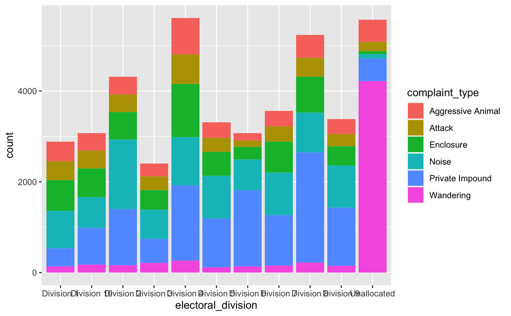

```r
animal_complaints %>%
  group_by(electoral_division) %>%
  ggplot(aes(x = electoral_division, fill = complaint_type)) +
  geom_bar()
```

```r
# note, this doesn't take into account population
```

I’ve pivoted the data longer, so the regions and counts of outcomes have their own column. This will make analysis easier, as each column has only one variable

```r
animal_outcomes_tidy <- animal_outcomes %>%
  pivot_longer(act:wa, names_to = "region", values_to = "count")
```

Adding proportions to animal_outcomes_tidy:

We’re adding proportions

```r
# grouping by region
animal_outcomes_tidy %>%
  group_by(region) %>%
  summarise(prop = sum(count, na.rm = TRUE) / sum(total, na.rm = TRUE))
```

| region | prop |
| --- | --- |
| act | 0.04830208 |
| nsw | 0.23216853 |
| nt | 0.04958460 |
| qld | 0.30855568 |
| sa | 0.07591665 |
| tas | 0.03374546 |
| vic | 0.23736058 |
| wa | 0.02116377 |

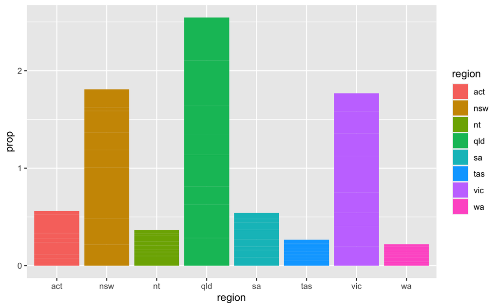

```r
animal_outcomes_tidy %>%
  group_by(outcome, region) %>%
  summarise(prop = sum(count, na.rm = TRUE) / sum(total, na.rm = TRUE)) %>%
  ggplot(aes(x = region, y = prop, fill = region)) +
  geom_col()
```

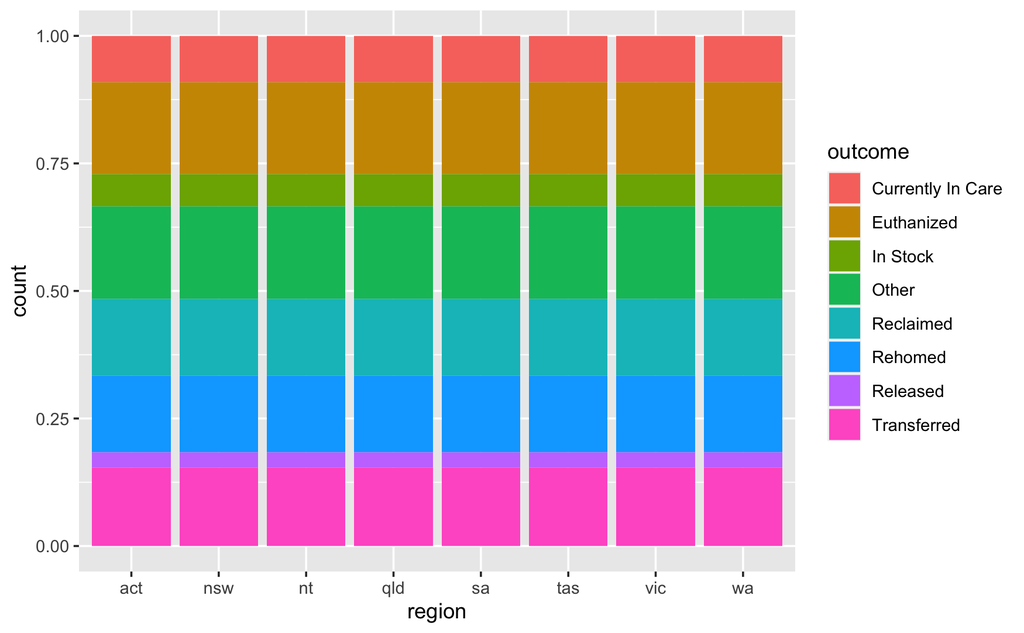

```r
animal_outcomes_tidy %>%
  ggplot(aes(x = region, fill = outcome)) +
  geom_bar(position = "fill")
```

```r
# animal_outcomes_tidy %>%
#   group_by(region, outcome) %>%
#   summarise(prop = sum(count, na.rm = TRUE) / sum(total, na.rm = TRUE)) %>%
#   ggplot(aes(x = region, y = prop, fill = outcome)) +
#   geom_col()

animal_outcomes
```

| year | animal_type | outcome | act | nsw | nt | qld | sa | tas | vic | wa | total |
| --- | --- | --- | --- | --- | --- | --- | --- | --- | --- | --- | --- |
| 1999 | Dogs | Reclaimed | 610 | 3140 | 205 | 1392 | 2329 | 516 | 7130 | 1 | 15323 |
| 1999 | Dogs | Rehomed | 1245 | 7525 | 526 | 5489 | 1105 | 480 | 4908 | 137 | 21415 |
| 1999 | Dogs | Other | 12 | 745 | 955 | 860 | 380 | 168 | 1001 | 6 | 4127 |
| 1999 | Dogs | Euthanized | 360 | 9221 | 9 | 9214 | 1701 | 599 | 5217 | 18 | 26339 |
| 1999 | Cats | Reclaimed | 111 | 201 | 22 | 206 | 157 | 31 | 884 | 0 | 1612 |
| 1999 | Cats | Rehomed | 1442 | 3913 | 269 | 3901 | 1055 | 752 | 3768 | 62 | 15162 |
| 1999 | Cats | Other | 0 | 447 | 0 | 386 | 46 | 124 | 1501 | 5 | 2509 |
| 1999 | Cats | Euthanized | 1007 | 8205 | 847 | 10554 | 3415 | 1056 | 6113 | 5 | 31202 |
| 1999 | Horses | Reclaimed | 0 | 0 | 1 | 0 | 2 | 1 | 87 | 0 | 91 |
| 1999 | Horses | Rehomed | 1 | 12 | 3 | 3 | 10 | 0 | 19 | 0 | 48 |

[output cut: 654 more lines]

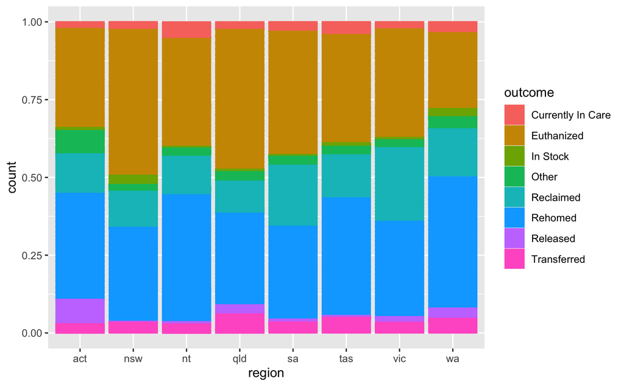

```r
animal_outcomes_tidy %>%
  group_by(region) %>%
  ggplot(aes(x = region, y = count, fill = outcome, col = outcome)) +
  geom_col(position = "fill")
```

At first glance, qld and nsw have a huge amount of euthanizations.